# Data Wrangling and Visualisation

Intro2R crash course: Session 2 of 2

Author: [Song, Xiao Ping](https://xp-song.github.io)

Last updated on 2022-10-18

In this lesson, we will be analysing the [Kaggle Machine Learning and Data Science Survey 2018](https://www.kaggle.com/kaggle/kaggle-survey-2018). The industry-wide survey presents the state of data science and machine learning. It was published in as raw a format as possible while ensuring the anonymity of respondents. We will only be analysing the multiple choice responses, which we will later assign to variable `multi`.

**Credit:** Our analysis includes code adapted from R Notebooks created by the Kaggle users [Heads or Tails](https://www.kaggle.com/headsortails/what-we-do-in-the-kernels-a-kaggle-survey-story) and [Jose Berengueres](https://www.kaggle.com/harriken/storytelling-the-2018-kaggle-survey).

# 1 Preparation

## 1.1 R Packages

Install and load necessary packages on your computer:

**[tidyverse](https://www.tidyverse.org/packages/):** A collection of packages commonly used for data analyses ([readr](https://readr.tidyverse.org), [tidyr](https://tidyr.tidyverse.org), [purr](https://purrr.tidyverse.org), [dplyr](https://dplyr.tidyverse.org), [ggplot2](https://ggplot2.tidyverse.org), [tibble](https://tibble.tidyverse.org))

```r
install.packages("tidyverse") # only need to do this once
library(tidyverse)
```

## 1.2 Load data

We will import our tabular data as [tibbles](https://cran.r-project.org/web/packages/tibble/vignettes/tibble.html) using `read_csv()`. Tibbles are a modern take on dataframes in the tidyverse. They impose stricter rules that avoid hassle/errors often associated with dataframes. For example, they…

- Never change the input type (e.g. character strings will not be converted to factors)
- Never change variale names (e.g. will not replace white space with `.`)
- Never use `row.names()`
- Always return another tibble during subsetting operations

```r
multi <- read_csv("../data/kaggle-survey-2018_mcq.csv", skip = 1)

#We skip the first line of the .csv file. The next line contains the survey questions that become the colnames

#read_csv() is a function in library(readr)
#readr::read_csv() can help you remember which package a function is from
```

## 1.3 Examine data

- Use `colnames()` to examine column names.
  - They are super-long sentences with white spaces, so we need to wrap the entire colname with backticks (e.g. `` multi$`Duration (in seconds)` ``)
  - This is not very feasible/readable code
  - We’ll abbreviate the colnames later on as we analyse each topic in the survey.
- Use `summary()` or `str()` to examine the data summary/structure.
- Use `head()` to preview first few rows of data

## 1.4 Convert data type

MCQ data are categorical with discrete levels. Tibbles import text as *character* format by default. Let’s change them to *factors* using `mutate_if()`.

- Use the pipe operator `%>%` from `library(dplyr)` to manipulate data in stages
  - It is a key operater often used in the `tidyverse`.
  - Rather than using nested brackets, the ‘pipeline’ is highly readable and follows a logical sequence.

```r
multi <- multi %>%
  mutate_if(is.character, as.factor)
```

# 2 Survey analysis

Number of respondents: *23859*

## 2.1 Duration

Let’s first abbreviate the colname `` `Duration (in seconds)` `` to `duration` using `rename()`, and change the units from seconds to minutes using `mutate()`.

```r
multi <- multi %>%
  rename(duration = `Duration (in seconds)`) %>% #rename column
  mutate(duration = duration/60) #change to minutes (use new colname)
```

Next, we plot a histogram using the function `ggplot()` from `library(ggplot2)`, a very popular package used for data visualisation (see [cheatsheet](https://github.com/rstudio/cheatsheets/blob/master/data-visualization-2.1.pdf)).

Three basic steps (linked with the `+` sign):  
1. Provide *data*  
2. Assign your data *variables* to *aesthetics*  
3. Assign the graphical *primitives*

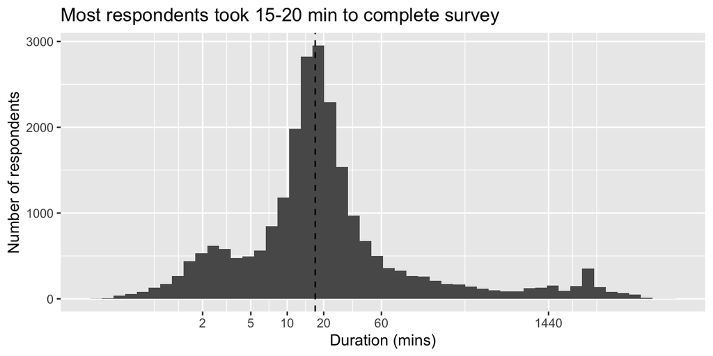

*Note: The dashed line denotes the median survey duration. The x-axis has been transformed to a logarithmic scale.*

```r
multi %>% #provide data
  ggplot(aes(duration)) + #assign variable 'duration' to aes()
  geom_histogram(bins = 50) + #graphical primitive
  geom_vline(xintercept = median(multi$duration), linetype = 2) + #graphical primitive

  scale_x_log10(breaks = c(2, 5, 10, 20, 60, 1440)) + #address extreme x-values

  #customisation
  labs(x = "Duration (mins)", y = "Number of respondents") + #change axis labels
  ggtitle("Most respondents took 15-20 min to complete survey") #add figure title
```

- Some respondents finished the survey in < 2 mins! They may have rushed it or left it incomplete.
- Some respondents probably left the browser tab open for a loong time.